# Projekt1-etap2

Filip Binkiewicz, Wojciech Szymański

W tym etapie zajmiemy się testowaniem różnych klasyfikatorów. Najpierw wczytujemy dane Rak

```r
load("C:/Users/ojro72/Desktop/Rak.rda")
```

W etapie 1 uzyskaliśmy zbiór istotnych cech, które teraz zapiszemy w wektorze `Nazwy`. Nastepnie utworzymy `Zbiór_Cechy`, który będzie zawierał dane pacjentów z istotnymi cechami. Zbudujemy klasyfikatory na zbiorze treningowym , natomiast w kolejnym kroku porównamy jakość przeprowadzonych klasyfikacji.

```r
Nazwy <- c("death1y","age","ACTR3C","AQP9","CLEC5A","CSNK1D","CTSB","CTSD","GPNMB","HK3","LRRC61","LSP1","MLPH","NCF2","NRG1","PLAUR","SLC11A1","SLC17A9","STAG2","STC1","TBL1XR1")

Zbior_Cechy <- Rak[,Nazwy]

library("caret")
wybor<-createDataPartition(as.factor(Zbior_Cechy$death1y), p=0.75, list=FALSE)

Zbior_Trening <- Zbior_Cechy[wybor,]
Zbior_Testowy <- Zbior_Cechy[-wybor,]


ZC <- Zbior_Cechy
ZC$death1y <- as.factor(Zbior_Cechy$death1y)
Zb <- Zbior_Trening
Zb$death1y <- as.factor(Zbior_Trening$death1y)
Zbt <- Zbior_Testowy
Zbt$death1y <- as.factor(Zbior_Testowy$death1y)
```

## Klasyfikatory

#### 1. Regresja logistyczna

Pierwszym testowanym klasyfikatorem jest regresja logistyczna

```r
Regresja <- glm(death1y~.,Zbior_Trening, family="binomial")
summary(Regresja)
```

```
##
## Call:
## glm(formula = death1y ~ ., family = "binomial", data = Zbior_Trening)
##
## Deviance Residuals:
##      Min        1Q    Median        3Q       Max
## -2.48172  -0.49535  -0.05655   0.66765   2.91479
##
## Coefficients:
##             Estimate Std. Error z value Pr(>|z|)
## (Intercept)  0.57306    2.74751   0.209   0.8348
## age          0.00290    0.02960   0.098   0.9219
## ACTR3C      -0.11483    0.37730  -0.304   0.7609
## AQP9        -0.18273    0.33056  -0.553   0.5804
## CLEC5A      -0.32559    0.25531  -1.275   0.2022
## CSNK1D      -4.63460    1.60129  -2.894   0.0038 **
## CTSB        -0.03959    0.88066  -0.045   0.9641
## CTSD         0.07737    0.98597   0.078   0.9375
## GPNMB       -0.61297    0.46967  -1.305   0.1919
## HK3          0.27258    0.56339   0.484   0.6285
## LRRC61      -0.46093    0.30134  -1.530   0.1261
## LSP1         0.10296    0.49776   0.207   0.8361
## MLPH        -0.19179    0.24043  -0.798   0.4250
## NCF2         0.49879    0.84507   0.590   0.5550
## NRG1        -0.46711    0.18936  -2.467   0.0136 *
## PLAUR       -1.03635    0.83394  -1.243   0.2140
## SLC11A1      0.20871    0.58181   0.359   0.7198
## SLC17A9      0.88623    0.53478   1.657   0.0975 .
## STAG2        0.97462    1.00260   0.972   0.3310
## STC1         0.16941    0.31337   0.541   0.5888
## TBL1XR1      2.19784    1.51702   1.449   0.1474
## ---
## Signif. codes:  0 '***' 0.001 '**' 0.01 '*' 0.05 '.' 0.1 ' ' 1
##
## (Dispersion parameter for binomial family taken to be 1)
##
##     Null deviance: 131.687  on 94  degrees of freedom
## Residual deviance:  73.124  on 74  degrees of freedom
## AIC: 115.12
##
## Number of Fisher Scoring iterations: 6
```

Ostatnia z kolumn opisujących zmienne objaśniające mówi o istotności każdej ze zmiennych. Jak widzimy większość zmiennych model uznaje jednak za niestotne, spróbujemy zatem poprawić naszą regresję funkcją `step`

#### 2. Poprawiona regresja logistyczna metodą backward

```r
Reg_back<-step(Regresja,method="backward")
```

```r
summary(Reg_back)
```

```
##
## Call:
## glm(formula = death1y ~ CSNK1D + LRRC61 + NRG1 + PLAUR + SLC17A9 +
##     STAG2, family = "binomial", data = Zbior_Trening)
##
## Deviance Residuals:
##     Min       1Q   Median       3Q      Max
## -2.3080  -0.5599  -0.1252   0.8075   1.8313
##
## Coefficients:
##             Estimate Std. Error z value Pr(>|z|)
## (Intercept)   0.5663     0.6729   0.842  0.40006
## CSNK1D       -3.7257     1.1734  -3.175  0.00150 **
## LRRC61       -0.4097     0.1743  -2.351  0.01872 *
## NRG1         -0.4478     0.1639  -2.732  0.00629 **
## PLAUR        -1.1642     0.4399  -2.646  0.00814 **
## SLC17A9       0.8538     0.4365   1.956  0.05046 .
## STAG2         1.2160     0.7617   1.596  0.11041
## ---
## Signif. codes:  0 '***' 0.001 '**' 0.01 '*' 0.05 '.' 0.1 ' ' 1
##
## (Dispersion parameter for binomial family taken to be 1)
##
##     Null deviance: 131.687  on 94  degrees of freedom
## Residual deviance:  80.372  on 88  degrees of freedom
## AIC: 94.372
##
## Number of Fisher Scoring iterations: 5
```

#### 3. Drzewo z pakietu party

Kolejnym narzędziem pomocnym w klasyfikacji są drzewa decyzyjne, które charakteryzują się dość słabą stabilnością

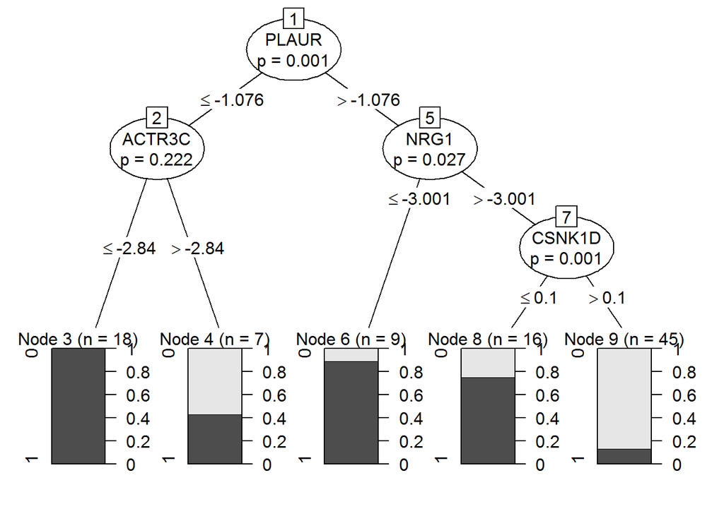

```r
library("party")
Drzewo <- ctree(death1y~., data=Zb, controls= ctree_control(testtype = "Bonferroni",mincriterion = 0.5))
plot(Drzewo)
```

#### 4. Las

Klasyfikatorem o większej stabilności od drzew jest las

```r
library("randomForest")
set.seed(1)
Las<-randomForest(death1y~.,data=Zb,importance=TRUE,proximity=TRUE)
Las
```

```
##
## Call:
##  randomForest(formula = death1y ~ ., data = Zb, importance = TRUE,      proximity = TRUE)
##                Type of random forest: classification
##                      Number of trees: 500
## No. of variables tried at each split: 4
##
##         OOB estimate of  error rate: 29.47%
## Confusion matrix:
##    0  1 class.error
## 0 34 14   0.2916667
## 1 14 33   0.2978723
```

#### 5. Naiwny Bayes

Ostatnim testowanym przez nas klasyfikatorem będzie naiwny klasyfikator Bayesowski.Zakłada on jednak, że łączna gestość jest iloczynem gęstości brzegowych. W celu przetestowania jakości tego modelu pominiemy to założenie

```r
library("e1071")
Bayes <- naiveBayes(death1y~.,Zb)
Bayes
```

```
##
## Naive Bayes Classifier for Discrete Predictors
##
## Call:
## naiveBayes.default(x = X, y = Y, laplace = laplace)
##
## A-priori probabilities:
## Y
##         0         1
## 0.5052632 0.4947368
##
## Conditional probabilities:
##    age
## Y       [,1]     [,2]
##   0 63.16667 11.70258
##   1 56.55319 11.86300
##
##    ACTR3C
## Y        [,1]     [,2]
##   0 -2.013706 1.296445
##   1 -2.990780 1.454350
##
##    AQP9
## Y         [,1]     [,2]
##   0  0.7133750 1.661105
##   1 -0.8581277 2.467329
##
##    CLEC5A
## Y        [,1]     [,2]
##   0 1.9202812 1.450782
##   1 0.7578511 1.913746
##
##    CSNK1D
## Y        [,1]      [,2]
##   0 0.3263958 0.2167525
##   1 0.1547021 0.3007897
##
##    CTSB
## Y           [,1]      [,2]
##   0  0.634114583 0.8409323
```

[output cut: 56 more lines]

```
##
##    STAG2
## Y          [,1]      [,2]
##   0 -0.38350000 0.4912332
##   1 -0.02980851 0.3917460
##
##    STC1
## Y        [,1]     [,2]
##   0 -1.236740 1.945522
##   1 -2.292957 1.752774
##
##    TBL1XR1
## Y         [,1]      [,2]
##   0 -0.9714687 0.2698743
##   1 -0.7860213 0.2896710
```

Aby porównać stworzone klasyfikatory użyjemy kilku narzędzi: tablic kontygencji,K-fold cross-walidacjji oraz narysujemy krzywe ROC

## Ocena klasyfikatorów

### Tabele kontyngencji

Najpierw konstruujemy przewidywaną na podstawie skonstruowanych klasyfikatorów śmiertelność dla zbioru testowego przy pomocy `predict`. Potem zbudujemy odpowiadające im tablice

#### 1. Dla regresji logistycznej

```r
predykcja1 <- predict(Regresja, Zbior_Testowy,type="response")
predykcja1 <- round(predykcja1,digits=0)
table(predykcja = predykcja1,Tabela = Zbior_Testowy$death1y)
```

```
##          Tabela
## predykcja  0  1
##         0 10  3
##         1  5 12
```

#### 2. Dla poprawionej regresji logistycznej metodą backward

```r
predykcja2 <- predict(Reg_back, Zbior_Testowy,type="response")
predykcja2 <- round(predykcja2,digits=0)
table(predykcja = predykcja2,Tabela = Zbior_Testowy$death1y)
```

```
##          Tabela
## predykcja  0  1
##         0  5  3
##         1 10 12
```

#### 3. Dla drzewa z pakietu party

```r
predykcja3 <- predict(Drzewo, Zbt)
table(predykcja = predykcja3,Tabela = Zbt$death1y)
```

```
##          Tabela
## predykcja  0  1
##         0 12  6
##         1  3  9
```

#### 4. Dla lasu

```r
predykcja4 <-  predict(Las, Zbt)
table(predykcja = predykcja4,Tabela = Zbt$death1y)
```

```
##          Tabela
## predykcja  0  1
##         0  8  2
##         1  7 13
```

#### 5. Dla Naiwnego Bayesa

```r
predykcja5 <-  predict(Bayes, Zbt)
table(predykcja = predykcja5,Tabela = Zbt$death1y)
```

```
##          Tabela
## predykcja  0  1
##         0  9  3
##         1  6 12
```

Powyższe wynik sugerują, że najlepszym klasyfikatorem jest regresja logistyczna, gdyż najlepiej przewidziała stan pacjentów

### K-fold cross-walidacja

Kolejną metodą porównywania klasyfikatorów jest K-fold cross-walidacja. Wykonujemy ją dla k=10. Dzielimy naszych pacjentów na 10 rozłącznych grup. W każdym z 10 kroków bierzemy jedną grupę traktując ją jako zbiór testowy, natomiast pozostałych jako zbiór treningowy. Dla każdego z dziesięciu przypadków liczymy błąd predykcji i uśredniamy

```r
fold <- createFolds(Zbior_Cechy$death1y, k = 10)
```

#### 1. Dla regresji logistycznej

```r
blad1 <- lapply(fold, function(x) {
  predykcja1 <- round(predict(glm(death1y~.,Zbior_Cechy[-x,],family="binomial"),Zbior_Cechy[x,],type="response"),digits =0)
  real1 <- Zbior_Cechy[x, "death1y"]
  mean(abs(predykcja1-real1))
})
mean(as.numeric(blad1))
```

```
## [1] 0.2621795
```

#### 2. Dla regresji logistycznej poprawionej metodą backward

```r
blad2 <- lapply(fold, function(x) {
  predykcja2 <- round(predict(step(glm(death1y~.,Zbior_Cechy[-x,],family="binomial"),method="backward"),Zbior_Cechy[x,],type="response"),digits =0)
  real2 <- Zbior_Cechy[x, "death1y"]
  mean(abs(predykcja2-real2))
})
```

```r
mean(as.numeric(blad2))
```

```
## [1] 0.2858974
```

#### 3. Dla drzewa z pakietu party

```r
blad3 <- lapply(fold, function(x) {
  predykcja3 <- predict(ctree(death1y~., data=ZC[-x,], controls= ctree_control(testtype = "Bonferroni",mincriterion = 0.5)),ZC[x,])
  real3 <- ZC[x, "death1y"]
  mean(abs(as.numeric(predykcja3)-as.numeric(real3)))
})
mean(as.numeric(blad3))
```

```
## [1] 0.3807692
```

#### 4. Dla lasu

```r
blad4 <- lapply(fold, function(x) {
  predykcja4 <- predict(randomForest(death1y~.,data=ZC[-x,],importance=TRUE,proximity=TRUE),ZC[x,])
  real4 <- ZC[x, "death1y"]
  mean(abs(as.numeric(predykcja4)-as.numeric(real4)))
})
mean(as.numeric(blad4))
```

```
## [1] 0.2858974
```

#### 5. Dla Naiwnego Bayesa

```r
blad5 <- lapply(fold, function(x) {
  predykcja5 <- predict(naiveBayes(death1y~.,ZC[-x,]),ZC[x,])
  real5 <- ZC[x, "death1y"]
  mean(abs(as.numeric(predykcja5)-as.numeric(real5)))
})
mean(as.numeric(blad5))
```

```
## [1] 0.2852564
```

Wyniki błędów 10-fold cv

```
##  Regresja  Reg_popr    Drzewo       Las     Bayes
## 0.2621795 0.2858974 0.3807692 0.2858974 0.2852564
```

Widzimy, że również najlepiej wypada regresja logistyczna, co pozwala wysunąć wnioski iż jest to najlepszy klasyfikator

## Krzywe ROC

Na koniec przedstawimy jeszcze krzywe ROC, aby zobrazować wyniki. Interpretacja krzywych ROC jest dość prosta. Im większe pole pod wykresem tym lepszy klasyfikator

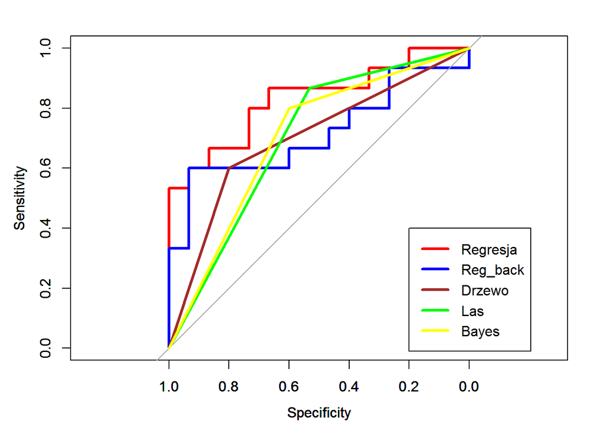